# Deep Learning Lab - Session 1

# Some Rules

- Questions & Discussions on **Moodle** first.
- Contact me at **`colman.dl.lab@gmail.com`** only after you tried on Moodle.
- Asking directly in mail without trying Moodle first will be ignored.

# Our Topics for Today

- Intro to Python.
- Math operations in python.
- Basic ML.
- Tensorflow.

# Into to Python

Python is awsome.

- Python is a great general-purpose programming language.
- code is often said to be almost like pseudocode, since it allows you to express very powerful ideas in very few lines of code while being very readable.
- Libraries like `numpy`, `scipy` and `matplotlib` make it even more powerful.

We will cover:

- Basic python data types to get you started.
- Numpy: arrays, indexing and more.
- Matplotlib: plotting, subplots and images.

# Basic Python

## Ints

```python
x = 3
print(x, type(x))
x = "bob"
print(x, type(x))
```

```
(3, <type 'int'>)
('bob', <type 'str'>)
```

# Floats

```python
y = 2.5
print(type(y))
print(y, y + 1, y * 2, y ** 2)
```

```
<type 'float'>
(2.5, 3.5, 5.0, 6.25)
```

# Operations

```python
x = 3
print(x + 1)   # Addition;
print(x - 1)   # Subtraction;
print(x * 2)   # Multiplication;
print(x ** 2)  # Exponentiation;
```

```
4
2
6
9
```

```python
x += 1
print(x)  # Prints "4"
x *= 2
print(x)  # Prints "8"
```

```
4
8
```

# Strings

```python
hello = 'hello'   # String literals can use single quotes
world = "world"   # or double quotes; it does not matter.
print(hello, len(hello))
```

```
('hello', 5)
```

# Concatenation

```python
hw = hello + ' ' + world  # String concatenation
print(hw)
```

```
hello world
```

# Formatting

```python
hw12 = '%s %s %d' % (hello, world, 12)  # printf style string formatting
print(hw12)
```

```
hello world 12
```

# Other Methods

```python
s = "hello"
print(s.capitalize())  # Capitalize a string; prints "Hello"
print(s.upper())       # Convert a string to uppercase; prints "HELLO"
print(s.replace('l', '(ell)'))  # Replace all instances of one substring with another;
                               # prints "he(ell)(ell)o"
print('  world '.strip())  # Strip leading and trailing whitespace; prints "world"
print('file.txt'.endswith('.txt'))  # Detect if the string ends with a given suffix
```

```
Hello
HELLO
he(ell)(ell)o
world
True
```

# Containers

# Lists

A list is the Python equivalent of an array, but is resizeable and can contain elements of different types.

```python
xs = [3, 1, 2]   # Create a list
print(xs, xs[2])
print(xs[-1])     # Negative indices count from the end of the list; prints "2"
```

```
([3, 1, 2], 2)
2
```

```python
xs[2] = 'foo'    # Lists can contain elements of different types
print(xs)
```

```
[3, 1, 'foo']
```

```python
xs.append('bar') # Add a new element to the end of the list
print(xs)
```

```
[3, 1, 'foo', 'bar']
```

```python
x = xs.pop()     # Remove and return the last element of the list
print(x, xs)
```

```
('bar', [3, 1, 'foo'])
```

```python
print 3 in xs # contains operator
```

```
True
```

# Slicing

```python
nums = range(5)    # range is a built-in function that creates a list of integers
print(nums)         # Prints "[0, 1, 2, 3, 4]"
print(nums[2:4])    # Get a slice from index 2 to 4 (exclusive); prints "[2, 3]"
print(nums[2:])    # Get a slice from index 2 to the end; prints "[2, 3, 4]"
print(nums[:2])     # Get a slice from the start to index 2 (exclusive); prints "[0, 1]"
print(nums[:])      # Get a slice of the whole list; prints ["0, 1, 2, 3, 4]"
print(nums[:-1])    # Slice indices can be negative; prints ["0, 1, 2, 3]"
nums[2:4] = [8, 9] # Assign a new sublist to a slice
print(nums)         # Prints "[0, 1, 8, 9, 4]"
```

```
[0, 1, 2, 3, 4]
[2, 3]
[2, 3, 4]
[0, 1]
[0, 1, 2, 3, 4]
[0, 1, 2, 3]
[0, 1, 8, 9, 4]
```

# Loops

```python
animals = ['cat', 'dog', 'monkey']
for animal in animals:
    print(animal)
```

```
cat
dog
monkey
```

```python
animals = ['cat', 'dog', 'monkey']
for idx, animal in enumerate(animals):
    print('#%d: %s' % (idx + 1, animal))
```

```
#1: cat
#2: dog
#3: monkey
```

# List comprehensions

Create lists with one-liners

```python
nums = [0, 1, 2, 3, 4]
squares = []
for x in nums:
    squares.append(x ** 2)
print(squares)
```

```
[0, 1, 4, 9, 16]
```

```python
nums = [0, 1, 2, 3, 4]
squares = [x ** 2 for x in nums]
print(squares)
```

```
[0, 1, 4, 9, 16]
```

```python
nums = [0, 1, 2, 3, 4]
even_squares = [x ** 2 for x in nums if x % 2 == 0]
print(even_squares)
```

```
[0, 4, 16]
```

# Dictionaries

A dictionary stores (key, value) pairs, similar to a `Map` in Java. You can use it like this:

```python
d = {'cat': 'cute', 'dog': 'furry'}  # Create a new dictionary with some data
print(d['cat'])       # Get an entry from a dictionary; prints "cute"
print('cat' in d)     # Check if a dictionary has a given key; prints "True"
```

```
cute
True
```

```python
d['fish'] = 'wet'    # Set an entry in a dictionary
print(d['fish'])      # Prints "wet"
```

```
wet
```

```python
print('monkey' in d)
print('cat' in d)
```

```
False
True
```

It is easy to iterate over the keys in a dictionary:

```python
d = {'person': 2, 'cat': 4, 'spider': 8}
for animal in d:
    legs = d[animal]
    print('A %s has %d legs' % (animal, legs))
```

```
A person has 2 legs
A spider has 8 legs
A cat has 4 legs
```

If you want access to keys and their corresponding values, use the items method:

```python
d = {'person': 2, 'cat': 4, 'spider': 8}
for animal, legs in d.items():
    print('A %s has %d legs' % (animal, legs))
```

```
A person has 2 legs
A spider has 8 legs
A cat has 4 legs
```

Dictionary comprehensions: These are similar to list comprehensions, but allow you to easily construct dictionaries. For example:

```python
nums = [0, 1, 2, 3, 4]
even_num_to_square = {x: x ** 2 for x in nums if x % 2 == 0}
print(even_num_to_square)
```

```
{0: 0, 2: 4, 4: 16}
```

# Sets

A set is an unordered collection of distinct elements. As a simple example, consider the following:

```python
x = ['dog','cat','fish','cat']
print(x)
x = set(x)
print(x)
```

```
['dog', 'cat', 'fish', 'cat']
set(['fish', 'dog', 'cat'])
```

```python
x.add('mouse')
print(x)
print(len(x))
```

```
set(['fish', 'mouse', 'dog', 'cat'])
4
```

# Tuples

A tuple is an (immutable) ordered list of values. A tuple is in many ways similar to a list; one of the most important differences is that tuples can be used as keys in dictionaries and as elements of sets, while lists cannot. Here is a trivial example:

```python
d = {(x, x + 1): x for x in range(10)}  # Create a dictionary with tuple keys
t = (5, 6)       # Create a tuple
print(type(t))
print(d[t])
print(d[(1, 2)])
```

```
<type 'tuple'>
5
1
```

# Functions

```python
def sign(x):
    if x > 0:
        return 'positive'
    elif x < 0:
        return 'negative'
    else:
        return 'zero'

for x in [-1, 0, 1]:
    print(sign(x))
```

```
negative
zero
positive
```

We will often define functions to take optional keyword arguments, like this:

```python
def hello(name, loud=False):
    if loud:
        print('HELLO, %s' % name.upper())
    else:
        print('Hello, %s!' % name)

hello('Bob')
hello('Fred', loud=True)
```

```
Hello, Bob!
HELLO, FRED
```

# Classes

```python
class Greeter:

    # Constructor
    def __init__(self, name):
        self.name = name  # Create an instance variable

    # Instance method
    def greet(self, loud=False):
        if loud:
            print('HELLO, %s!' % self.name.upper())
        else:
            print('Hello, %s' % self.name)

g = Greeter('Fred')  # Construct an instance of the Greeter class
g.greet()            # Call an instance method; prints "Hello, Fred"
g.greet(loud=True)   # Call an instance method; prints "HELLO, FRED!"
```

```
Hello, Fred
HELLO, FRED!
```

# Numpy

NumPy is a library for the Python programming language, adding support for large, multi-dimensional arrays and matrices, along with a large collection of high-level mathematical functions to operate on these arrays.

Basically, it lets you do math stuff efficiently.

First, lets import numpy

```python
import numpy as np
```

# Arrays

A numpy array is a grid of values, all of the same type, and is indexed by a tuple of nonnegative integers. The number of dimensions is the rank of the array; the shape of an array is a tuple of integers giving the size of the array along each dimension.

You can initialize arrays using python lists (or nested lists).

```python
a = np.array([1, 2, 3])  # Create a rank 1 array
print(type(a), a.shape, a[0], a[1], a[2])
a[0] = 5                 # Change an element of the array
print(a)
```

```
(<type 'numpy.ndarray'>, (3,), 1, 2, 3)
[5 2 3]
```

We can also create a 2d array (a matrix)

```python
b = np.array([[1,2,3],[4,5,6]])   # Create a rank 2 array
print b
print b.shape
print b[0, 0], b[0, 1], b[1, 0]
```

```
[[1 2 3]
 [4 5 6]]
(2, 3)
1 2 4
```

Numpy also provides many functions to create arrays

```python
a = np.zeros((2,2))  # Create an array of all zeros
print a
```

```
[[ 0.  0.]
 [ 0.  0.]]
```

```python
b = np.ones((1,2))   # Create an array of all ones
print b
```

```
[[ 1.  1.]]
```

```python
c = np.full((2,2), 7) # Create a constant array
print c
```

```
[[7 7]
 [7 7]]
```

```python
d = np.eye(2)        # Create a 2x2 identity matrix
print d
```

```
[[ 1.  0.]
 [ 0.  1.]]
```

```python
e = np.random.random((2,2)) # Create an array filled with random values
print e
```

```
[[ 0.13014513  0.11484043]
 [ 0.36060727  0.00435611]]
```

# Array Indexing

Numpy offers several ways to index into arrays.

Slicing: Similar to Python lists, numpy arrays can be sliced. Since arrays may be multidimensional, you must specify a slice for each dimension of the array

```python
import numpy as np

# Create the following rank 2 array with shape (3, 4)
# [[ 1  2  3  4]
#  [ 5  6  7  8]
#  [ 9 10 11 12]]
a = np.array([[1,2,3,4], [5,6,7,8], [9,10,11,12]])

# Use slicing to pull out the subarray consisting of the first 2 rows
# and columns 1 and 2; b is the following array of shape (2, 2):
# [[2 3]
#  [6 7]]
b = a[:2, 1:3]
print b
```

```
[[2 3]
 [6 7]]
```

```python
row_r1 = a[1, :]    # Vector view of the second row of a
row_r2 = a[1:2, :]  # Marix view of the second row of a
print row_r1, row_r1.shape
print row_r2, row_r2.shape
```

```
[5 6 7 8] (4,)
[[5 6 7 8]] (1, 4)
```

We can also use conditions on arrays

```python
a = np.array([[1,2], [3, 4], [5, 6]])

bool_idx = (a > 2)  # Find the elements of a that are bigger than 2;
                    # this returns a numpy array of Booleans of the same
                    # shape as a, where each slot of bool_idx tells
                    # whether that element of a is > 2.

print bool_idx
```

```
[[False False]
 [ True  True]
 [ True  True]]
```

# Array Math Operations

Basic mathematical functions operate elementwise on arrays, and are available both as operator overloads and as functions in the numpy module

```python
x = np.array([[1,2],[3,4]], dtype=np.float64)
y = np.array([[5,6],[7,8]], dtype=np.float64)

# Elementwise sum; both produce the array
print x + y
print np.add(x, y)
```

```
[[  6.   8.]
 [ 10.  12.]]
[[  6.   8.]
 [ 10.  12.]]
```

```python
# Elementwise difference; both produce the array
print x - y
print np.subtract(x, y)
```

```
[[-4. -4.]
 [-4. -4.]]
[[-4. -4.]
 [-4. -4.]]
```

```python
# Elementwise product; both produce the array
print x * y
print np.multiply(x, y)
```

```
[[  5.  12.]
 [ 21.  32.]]
[[  5.  12.]
 [ 21.  32.]]
```

Note that unlike MATLAB, * is elementwise multiplication, not matrix multiplication. We instead use the dot function to compute inner products of vectors, to multiply a vector by a matrix, and to multiply matrices. dot is available both as a function in the numpy module and as an instance method of array objects

```python
x = np.array([[1,2],[3,4]])
y = np.array([[5,6],[7,8]])

v = np.array([9,10])
w = np.array([11, 12])

# Inner product of vectors; both produce 219
print v.dot(w)
print np.dot(v, w)
```

```
219
219
```

```python
# Matrix / vector product; both produce the rank 1 array [29 67]
print x.dot(v)
print np.dot(x, v)
```

```
[29 67]
[29 67]
```

```python
# Matrix / matrix product; both produce the rank 2 array
# [[19 22]
#  [43 50]]
print x.dot(y)
print np.dot(x, y)
```

```
[[19 22]
 [43 50]]
[[19 22]
 [43 50]]
```

Numpy provides many useful functions for performing computations on arrays; one of the most useful is `sum`:

```python
x = np.array([[1,2],[3,4]])

print np.sum(x)  # Compute sum of all elements; prints "10"
print np.sum(x, axis=0)  # Compute sum of each column; prints "[4 6]"
print np.sum(x, axis=1)  # Compute sum of each row; prints "[3 7]"
```

```
10
[4 6]
[3 7]
```

```python
print x
print x.T
```

```
[[1 2]
 [3 4]]
[[1 3]
 [2 4]]
```

# Plotting

The most important function in `matplotlib` is plot, which allows you to plot 2D data. Here is a simple example:

```python
import matplotlib.pyplot as plt
%matplotlib inline
```

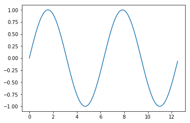

```python
# Compute the x and y coordinates for points on a sine curve
x = np.arange(0, 4 * np.pi, 0.1)
y = np.sin(x)

# Plot the points using matplotlib
plt.plot(x, y)
```

With just a little bit of extra work we can easily plot multiple lines at once, and add a title, legend, and axis labels:

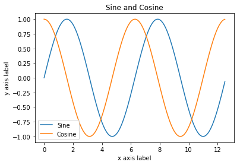

```python
y_cos = np.cos(x)
y_sin = np.sin(x)

# Plot the points using matplotlib
plt.plot(x, y_sin)
plt.plot(x, y_cos)
plt.xlabel('x axis label')
plt.ylabel('y axis label')
plt.title('Sine and Cosine')
plt.legend(['Sine', 'Cosine'])
```

# Subplots

You can plot different things in the same figure using the subplot function. Here is an example:

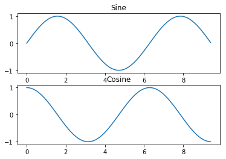

```python
# Compute the x and y coordinates for points on sine and cosine curves
x = np.arange(0, 3 * np.pi, 0.1)
y_sin = np.sin(x)
y_cos = np.cos(x)

# Set up a subplot grid that has height 2 and width 1,
# and set the first such subplot as active.
plt.subplot(2, 1, 1)

# Make the first plot
plt.plot(x, y_sin)
plt.title('Sine')

# Set the second subplot as active, and make the second plot.
plt.subplot(2, 1, 2)
plt.plot(x, y_cos)
plt.title('Cosine')

# Show the figure.
plt.show()
```